# CITS4009 Computational Data Analysis

Project 1 — Exploratory Data Analysis

Gaoyuan ZHANG* (22994257)

Aug 31, 2022

# 1 Introduction

This project uses the “US Accident Injury” dataset obtained from Data.gov, which is published by US Department of Labour and spans across 15 years (from 2000 to 2015). This dataset contains information on all accidents, injuries, and illnesses reported by mine operators and contractors.

# 2 Data loading, overview and set up

## 2.1 Load libraries

```r
library(ggplot2)
library(hexbin)
library(gridExtra)
library(ggthemes)
library(grid)
library(stringr)
library(tidyr)
library(lubridate,warn.conflicts = F)
library(data.table,warn.conflicts = F)
library(dplyr,warn.conflicts = F)
```

## 2.2 Setting up a plotting theme so that all charts look coherent

```r
project_theme <- theme_few() +
                  theme(plot.title = element_text(color = "darkred")) +
                  theme(strip.text.x = element_text(size = 16, colour = "#202020")) +
                  theme(plot.margin=margin(15,40,15,40))
```

## 2.3 Load the main data

```r
us_data <- read.csv("us_data_2000.csv")
```

# 3 Using R functions to explore the data

## 3.1 Using str() to analyze the data

```r
str(us_data)
```

[output not shown]

## 3.2 Using summary() to analyze the data

```r
summary(us_data)
```

[output not shown]

## 3.3 Using head() to view the first six rows

```r
head(us_data)
```

[output not shown]

# 4 Data cleaning and transformation

## 4.1 Convert some columns to better format

```r
us_data <- within(us_data,{
  # Parsing ID
  MINE_ID <- as.factor(MINE_ID)

  # Parsing dates
  ACCIDENT_DT <- as.Date(ACCIDENT_DT, "%d/%m/%Y")
  ACCIDENT_DT <- factor(ACCIDENT_DT)
})
```

```r
head(us_data)
```

[output not shown]

## 4.2 Dealing with the NA in each variable

Count the NA in each variable at first.

```r
count_na = function(df) {
    sapply(df, FUN = function(col) sum(is.na(col)) )
}
na_sum <- count_na(us_data)
NAexists = which(na_sum > 0)
na_sum[NAexists]
```

```
##   EQUIP_MODEL_NO SHIFT_BEGIN_TIME        TOT_EXPER       MINE_EXPER
##                1                9              360              333
##        JOB_EXPER  SCHEDULE_CHARGE    DAYS_RESTRICT        DAYS_LOST
##              328              673              543              422
##    CLOSED_DOC_NO
##             1138
```

However, in addition to “NA”, there are many values in the table like “?”, “NO VALUE FOUND” “9999” and null value are meaningless. So before we drop the existed NA, we must convert them to NA.(Why delete “999X” in “ACCIDENT_TIME”? Because this variable means the time accident occurred(24-hour clock). But there is not “99:9X” in our clock!)

```r
us_data <- within(us_data,{
  # Convert the "?" to NA
  UG_LOCATION[us_data$UG_LOCATION=="?"] <- NA
  UG_MINING_METHOD_CD[UG_MINING_METHOD_CD=="?"] <- NA
  UG_LOCATION_CD[UG_LOCATION_CD=="?"] <- NA
  MINING_EQUIP_CD[MINING_EQUIP_CD=="?"] <- NA
  EQUIP_MFR_CD[EQUIP_MFR_CD=="?"] <- NA
  EQUIP_MODEL_NO[EQUIP_MODEL_NO=="?"] <- NA
  OCCUPATION_CD[OCCUPATION_CD=="?"] <- NA
  ACTIVITY_CD[ACTIVITY_CD=="?"] <- NA
  INJURY_SOURCE_CD[INJURY_SOURCE_CD=="?"] <- NA
  NATURE_INJURY_CD[NATURE_INJURY_CD=="?"] <- NA
  INJ_BODY_PART_CD[INJ_BODY_PART_CD=="?"] <- NA

  # Convert the "NO VALUE FOUND" to NA
  ACTIVITY[ACTIVITY=="NO VALUE FOUND"] <- NA
  MINING_EQUIP[MINING_EQUIP=="NO VALUE FOUND"] <- NA
  INJURY_SOURCE[INJURY_SOURCE=="NO VALUE FOUND"] <- NA
  NATURE_INJURY[NATURE_INJURY=="NO VALUE FOUND"] <- NA
  INJ_BODY_PART[INJ_BODY_PART=="NO VALUE FOUND"] <- NA
  UG_LOCATION[UG_LOCATION=="NO VALUE FOUND"] <- NA
  UG_MINING_METHOD[UG_MINING_METHOD =="NO VALUE FOUND"] <- NA
  DEGREE_INJURY[DEGREE_INJURY =="NO VALUE FOUND"] <- NA
  EQUIP_MFR_NAME[EQUIP_MFR_NAME =="NO VALUE FOUND"] <- NA
  OCCUPATION[OCCUPATION =="NO VALUE FOUND"] <- NA

  # Convert the "999X" to NA in the column "ACCIDENT_TIME"
  ACCIDENT_TIME[ACCIDENT_TIME == "9996"] <- NA
  ACCIDENT_TIME[ACCIDENT_TIME == "9997"] <- NA
  ACCIDENT_TIME[ACCIDENT_TIME == "9998"] <- NA
  ACCIDENT_TIME[ACCIDENT_TIME == "9999"] <- NA

  # Convert the "" to NA
  CONTRACTOR_ID[CONTRACTOR_ID==""] <- NA
  EQUIP_MODEL_NO[EQUIP_MODEL_NO==""] <- NA
  TRANS_TERM[TRANS_TERM==""] <-NA
})
```

After converting these meaningless value, we can check the count of NA again.

```r
na_sum <- count_na(us_data)
NAexists = which(na_sum > 0)
na_sum[NAexists]
```

```
##       CONTRACTOR_ID       ACCIDENT_TIME       DEGREE_INJURY      UG_LOCATION_CD
##                1830                 139                  11                1284
##         UG_LOCATION UG_MINING_METHOD_CD    UG_MINING_METHOD     MINING_EQUIP_CD
##                1284                1392                1392                1053
##        MINING_EQUIP        EQUIP_MFR_CD      EQUIP_MFR_NAME      EQUIP_MODEL_NO
##                1053                1056                1056                1637
##    SHIFT_BEGIN_TIME           TOT_EXPER          MINE_EXPER           JOB_EXPER
##                   9                 360                 333                 328
##       OCCUPATION_CD          OCCUPATION         ACTIVITY_CD            ACTIVITY
##                 242                 242                 239                 239
##    INJURY_SOURCE_CD       INJURY_SOURCE    NATURE_INJURY_CD       NATURE_INJURY
##                 238                 238                 242                 242
##    INJ_BODY_PART_CD       INJ_BODY_PART     SCHEDULE_CHARGE       DAYS_RESTRICT
##                 242                 242                 673                 543
##           DAYS_LOST          TRANS_TERM       CLOSED_DOC_NO
##                 422                 267                1138
```

From the NAs table above we also can find a special phenomena: Some variables have similar number of NAs! For example,

INJURY_SOURCE_CD, INJURY_SOURCE are 238 ACTIVITY_CD, ACTIVITY are 239 OCCUPATION_CD, OCCUPATION, NATURE_INJURY_CD, NATURE_INJURY, INJ_BODY_PART_CD, INJ_BODY_PART are 242

So they most likely comes from the same rows of data, and we can use summary() to prove.

```r
summary(us_data[is.na(us_data$ACTIVITY_CD),c("ACTIVITY","INJURY_SOURCE_CD","INJURY_SOURCE","OCCUPATION_CD", "OCCUPATION", "NATURE_INJURY_CD", "NATURE_INJURY", "INJ_BODY_PART_CD", "INJ_BODY_PART")])
```

```
##    ACTIVITY         INJURY_SOURCE_CD   INJURY_SOURCE      OCCUPATION_CD
##  Length:239         Length:239         Length:239         Length:239
##  Class :character   Class :character   Class :character   Class :character
##  Mode  :character   Mode  :character   Mode  :character   Mode  :character
##   OCCUPATION        NATURE_INJURY_CD   NATURE_INJURY      INJ_BODY_PART_CD
##  Length:239         Length:239         Length:239         Length:239
##  Class :character   Class :character   Class :character   Class :character
##  Mode  :character   Mode  :character   Mode  :character   Mode  :character
##  INJ_BODY_PART
##  Length:239
##  Class :character
##  Mode  :character
```

```r
newdata <- us_data[!is.na(us_data$OCCUPATION_CD),]
newdata <- newdata[!is.na(newdata$ACTIVITY_CD),]
```

Also, some variables only have a few NAs, such as DEGREE_INJURY, SHIFT_BEGIN_TIME, ACCIDENT_TIME and TRANS_TERM. If we remove the row where NA is, we won’t reduce our data volume much. So it’s very safely to remove them.

```r
newdata <- newdata[!is.na(us_data$DEGREE_INJURY),]
newdata <- newdata[!is.na(newdata$SHIFT_BEGIN_TIME),]
newdata <- newdata[!is.na(newdata$ACCIDENT_TIME),]
newdata <- newdata[!is.na(newdata$TRANS_TERM),]
```

Now we check the NAs that still exist again.

```r
na_sum <- count_na(newdata)
NAexists = which(na_sum > 0)
na_sum[NAexists]
```

```
##       CONTRACTOR_ID      UG_LOCATION_CD         UG_LOCATION UG_MINING_METHOD_CD
##                1469                1121                1121                1195
##    UG_MINING_METHOD     MINING_EQUIP_CD        MINING_EQUIP        EQUIP_MFR_CD
##                1195                 806                 806                 807
##      EQUIP_MFR_NAME      EQUIP_MODEL_NO           TOT_EXPER          MINE_EXPER
##                 807                1326                 104                  76
##           JOB_EXPER     SCHEDULE_CHARGE       DAYS_RESTRICT           DAYS_LOST
##                  78                 566                 423                 319
##       CLOSED_DOC_NO
##                 805
```

We have known that some variables of them are numeric variable, such as TOT_EXPER, MINE_EXPER and JOB_EXPER. Also, the number of these rows with missing data is not a large proportion of the total, so we can consider to use the mean to deal with replace their NAs.

```r
# Replace the missing values with mean
group1 <- us_data %>%
        group_by(DEGREE_INJURY) %>%
        summarise(TOT_EXPER = mean(TOT_EXPER, na.rm = T))
group2 <- us_data %>%
        group_by(DEGREE_INJURY) %>%
        summarise(MINE_EXPER = mean(MINE_EXPER, na.rm = T))
group3 <- us_data %>%
        group_by(DEGREE_INJURY) %>%
        summarise(JOB_EXPER = mean(JOB_EXPER, na.rm = T))
meanTOT <- mean(newdata$TOT_EXPER, na.rm=T)
newdata$TOT_EXPER <- ifelse(is.na(newdata$TOT_EXPER),meanTOT,newdata$TOT_EXPER)
meanMINE <- mean(newdata$MINE_EXPER, na.rm=T)
newdata$MINE_EXPER <- ifelse(is.na(newdata$MINE_EXPER),meanMINE,newdata$MINE_EXPER)
meanJOB <- mean(newdata$JOB_EXPER, na.rm=T)
newdata$JOB_EXPER <- ifelse(is.na(newdata$JOB_EXPER),meanJOB,newdata$JOB_EXPER)
```

Check the outliers of TOT_EXPER, MINE_EXPER and JOB_EXPER after replacing.

```r
#TOT_EXPERMINE_EXPER
stat1 <- boxplot.stats(newdata$TOT_EXPER)
stat1$n
```

```
## [1] 1622
```

```r
(stat1$stats)
```

```
## [1]  0.01  2.11  8.00 17.00 39.00
```

```r
length(stat1$out)
```

```
## [1] 13
```

```r
cat("min max outlying TOT_EXPER are:", min(stat1$out),",",max(stat1$out),"\n")
```

```
## min max outlying TOT_EXPER are: 39.92 , 46
```

```r
#MINE_EXPER
stat2 <- boxplot.stats(newdata$MINE_EXPER)
stat2$n
```

```
## [1] 1622
```

```r
(stat2$stats)
```

```
## [1]  0.01  0.94  3.38  8.96 20.69
```

```r
length(stat2$out)
```

```
## [1] 154
```

```r
cat("min max outlying MINE_EXPER are:", min(stat2$out),",",max(stat2$out),"\n")
```

```
## min max outlying MINE_EXPER are: 21 , 43
```

```r
#JOB_EXPER
stat2 <- boxplot.stats(newdata$JOB_EXPER)
stat2$n
```

```
## [1] 1622
```

```r
(stat2$stats)
```

```
## [1]  0.01  1.00  4.00  9.87 23.15
```

```r
length(stat2$out)
```

```
## [1] 110
```

```r
cat("min max outlying TOT_EXPER are:", min(stat2$out),",",max(stat2$out))
```

```
## min max outlying TOT_EXPER are: 23.21 , 41.73
```

Analyze the number of NA each variables

```r
apply(is.na(newdata), 2, sum)
```

```
##             MINE_ID       CONTROLLER_ID     CONTROLLER_NAME         OPERATOR_ID
##                   0                   0                   0                   0
##       OPERATOR_NAME       CONTRACTOR_ID         DOCUMENT_NO          SUBUNIT_CD
##                   0                1469                   0                   0
##             SUBUNIT         ACCIDENT_DT              CAL_YR             CAL_QTR
##                   0                   0                   0                   0
##           FISCAL_YR          FISCAL_QTR       ACCIDENT_TIME    DEGREE_INJURY_CD
##                   0                   0                   0                   0
##       DEGREE_INJURY       FIPS_STATE_CD      UG_LOCATION_CD         UG_LOCATION
##                   0                   0                1121                1121
## UG_MINING_METHOD_CD    UG_MINING_METHOD     MINING_EQUIP_CD        MINING_EQUIP
##                1195                1195                 806                 806
##        EQUIP_MFR_CD      EQUIP_MFR_NAME      EQUIP_MODEL_NO    SHIFT_BEGIN_TIME
##                 807                 807                1326                   0
##   CLASSIFICATION_CD      CLASSIFICATION    ACCIDENT_TYPE_CD       ACCIDENT_TYPE
##                   0                   0                   0                   0
##         NO_INJURIES           TOT_EXPER          MINE_EXPER           JOB_EXPER
##                   0                   0                   0                   0
##       OCCUPATION_CD          OCCUPATION         ACTIVITY_CD            ACTIVITY
##                   0                   0                   0                   0
##    INJURY_SOURCE_CD       INJURY_SOURCE    NATURE_INJURY_CD       NATURE_INJURY
##                   0                   0                   0                   0
##    INJ_BODY_PART_CD       INJ_BODY_PART     SCHEDULE_CHARGE       DAYS_RESTRICT
##                   0                   0                 566                 423
##           DAYS_LOST          TRANS_TERM   RETURN_TO_WORK_DT     IMMED_NOTIFY_CD
##                 319                   0                   0                   0
##        IMMED_NOTIFY     INVEST_BEGIN_DT           NARRATIVE       CLOSED_DOC_NO
##                   0                   0                   0                 805
##      COAL_METAL_IND
##                   0
```

We can see that after our data cleaning and transformation, most columns don’t have any NA. Only some variables have a large amount of NAs, such as UG_LOCATION_CD UG_LOCATION, UG_MINING_METHOD_CD, UG_MINING_METHOD, MINING_EQUIP_CD, MINING_EQUIP. However, there are really too many NAs for these variables. If we remove all of their NAs, it will seriously affect the completeness of the data set and the accuracy of the analysis of the relationships between other variables. So we need to keep them and create subsets for analysis where appropriate.

# 5 Visualisation and Analyzing

## 5.1 Analyzing the relationship between accident frequency and years

Using bar chart to count the frequency of accidents by year.

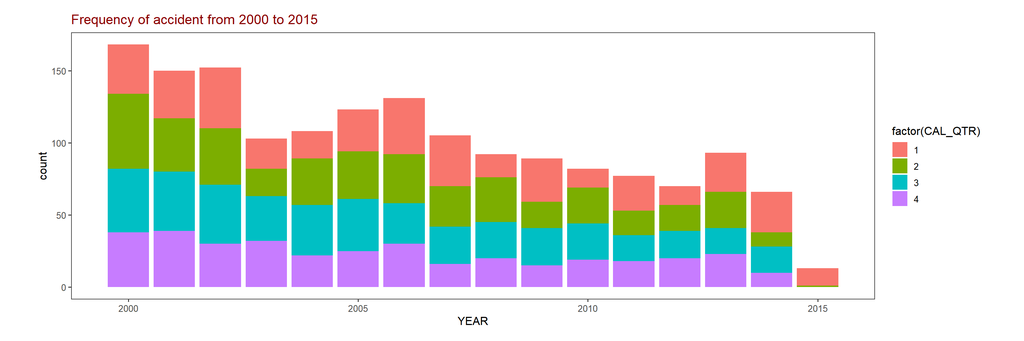

```r
ggplot(data = newdata)+
  geom_bar(aes(x = CAL_YR,fill=factor(CAL_QTR)),position="stack") +
  ggtitle("Frequency of accident from 2000 to 2015") + xlab("YEAR") +
  project_theme
```

We can see that the frequency of accident in Q3 and Q4 of 2015 are not available(probably because they haven’t been updated), so we consider data from 2000 to 2014. As a whole, the frequency of accidents is decreasing year by year. There will be special cases in some years, but overall it is becoming safer.

## 5.2 Analyzing the relationship between accident occurrence and time or quarter

Since the system of time is 24 hours, so the range of normal values is 0 to 2400.

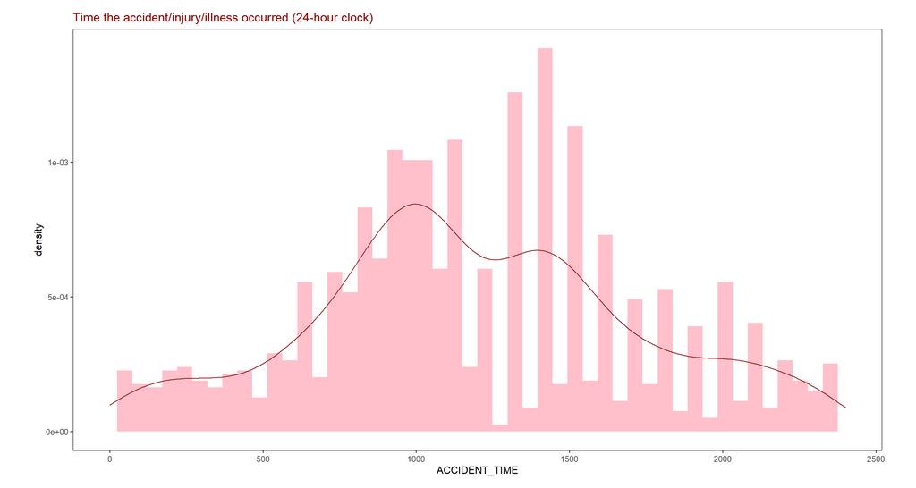

```r
ggplot(data = newdata, mapping = aes(x = ACCIDENT_TIME))+
   geom_histogram(aes(y=..density..), bins = 50, fill = "pink")+
   geom_density(color='darkred') +
   scale_x_continuous(limits=c(0, 2400))+
   ggtitle("Time the accident/injury/illness occurred (24-hour clock)") +
   project_theme
```

The histogram and density of accident occured time shows that seems to be a bi-modal distribution which reach the peak around 10am and 2pm, which also means that this time period is the most frequent period for accidents and the accident time was concentrated in the daytime. This may be because people usually stay at home in the evening, and some people also have the habit of siestas.

Use pie chart to count the frequency of accidents by quarter.

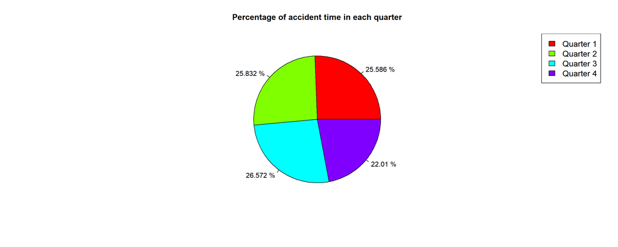

```r
freq = table(newdata$CAL_QTR)
piepercent<- paste(round(100*freq/sum(freq), 3), "%")

pie1=pie(freq,labels = piepercent,main="Percentage of accident time in each quarter",col = rainbow(length(freq)))
legend("topright",c("Quarter 1","Quarter 2","Quarter 3","Quarter 4"),cex=1.2,fill=rainbow(length(freq)))
```

We can see that the frequency of accidents by quarter is very evenly.

So we can draw a conclusion that accident the probability of an accident is closely related to the time of day, but not the quarter. We should focus on the time period with high probability of accidents and take appropriate safety measures.

## 5.3 Analyzing the location of accident/injury/illness occurred

We can create bar charts and pie to analyze the location within a mine where the accident/injury/illness occurred and make suggestions.

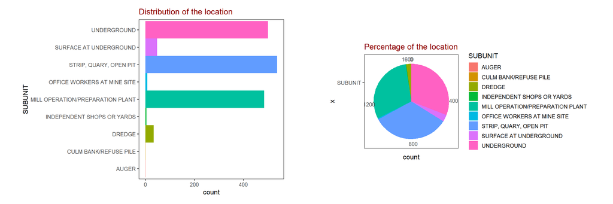

```r
p1 <- ggplot(data=newdata)+
  geom_bar(mapping = aes(x=SUBUNIT, fill=SUBUNIT), show.legend = FALSE, width =1)+
  ggtitle("Distribution of the location")+
  coord_flip()+
  project_theme
p2 <- ggplot(data=newdata, mapping=aes(x="SUBUNIT",fill=SUBUNIT))+
  geom_bar(stat="count",width=0.5,position='stack')+
  ggtitle("Percentage of the location")+
  coord_polar("y", start=0) +
  project_theme
grid.arrange(p1,p2,nrow=1)
```

We can see from the chart above, the three most likely locations for accidents are underground, strip, quary,open pit and mill operation/preparation plant. Therefore, workers should be extremely careful when working in these three places, and it’s important to take some safety measures and provide rescue support at any time.

## 5.4 Analyzing the body part that need special attention to protect by INJ_BODY_PART and DAYS_RESTRICT

Polar coordinate plot to analyze the distribution of the injury body part.

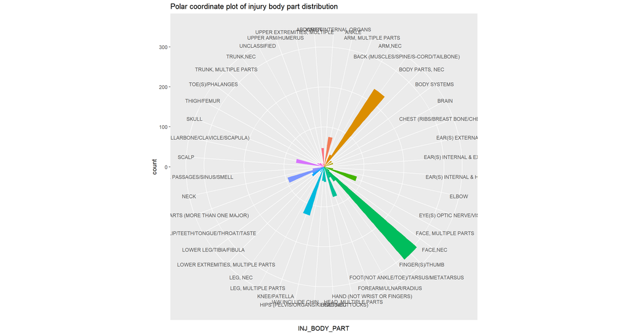

```r
ggplot(data=newdata)+
  geom_bar(mapping = aes(x=INJ_BODY_PART, fill=INJ_BODY_PART), show.legend = FALSE, width = 1)+
  ggtitle("Polar coordinate plot of injury body part distribution")+
  coord_polar()
```

Using scatter plot and the polar coordinate plot above to analyze the body part that need special attention to protect.

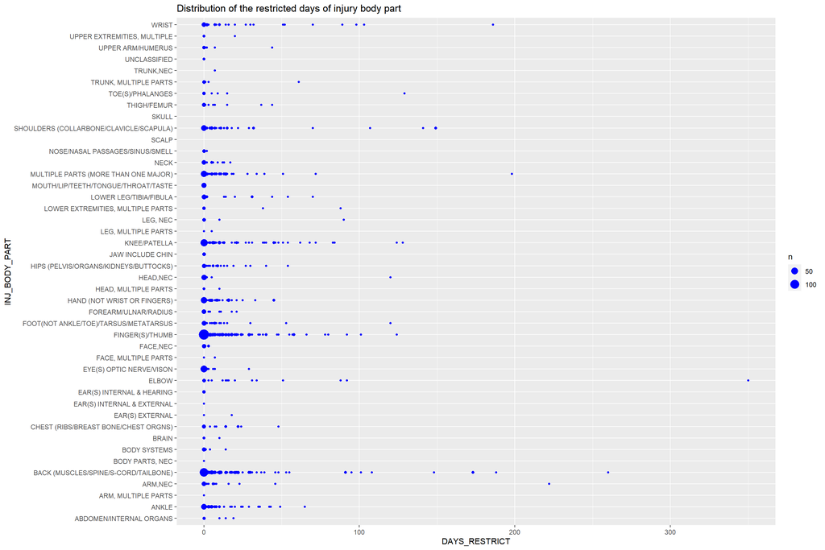

```r
ggplot(data = newdata) +
  geom_count(mapping = aes(x=DAYS_RESTRICT, y=INJ_BODY_PART),colour = "blue") +
  ggtitle("Distribution of the restricted days of injury body part")
```

It seems that human body part like fingers, knee, ankle and wrist are very vulnerable to injury. Although they can recover in a short time, they can relapse easily. Also, we should focus on the back, a body part that is prone to injury and takes a long time to heal. For these vulnerable body key parts, it’s important to remind workers to focus on protecting and raising awareness.

## 5.5 Analyzing the relationship between experience and degree of injure

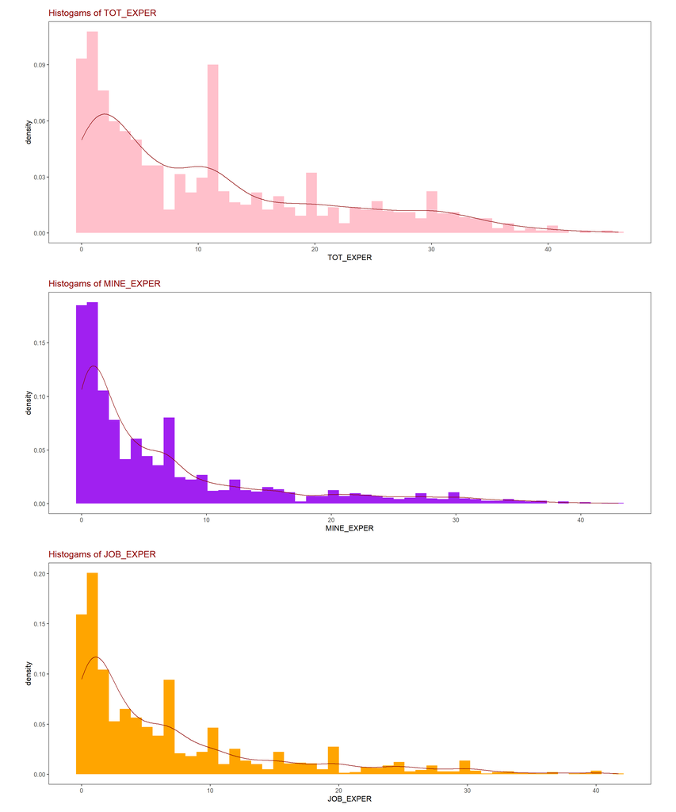

```r
p3 <- ggplot(data = newdata, mapping = aes(x = TOT_EXPER))+
        geom_histogram(aes(y=..density..), bins = 50, fill = "pink")+
        geom_density(color='darkred') +
        ggtitle("Histogams of TOT_EXPER") +
        project_theme
p4 <- ggplot(data = newdata, mapping = aes(x = MINE_EXPER))+
        geom_histogram(aes(y=..density..), bins = 50, fill = "purple")+
        geom_density(color='darkred') +
        ggtitle("Histogams of MINE_EXPER") +
        project_theme
p5 <- ggplot(data = newdata, mapping = aes(x = JOB_EXPER))+
        geom_histogram(aes(y=..density..), bins = 50, fill = "orange")+
        geom_density(color='darkred') +
        ggtitle("Histogams of JOB_EXPER") +
        project_theme
grid.arrange(p3,p4,p5,ncol=1)
```

We see that this all three plots above shows positively skewed distribution, which means any experience of the workers is not sufficient. Could the workers’ inadequate experience have led to an increase in the degree of injuries?

Now we’ll see the influence between degree injury of different experience

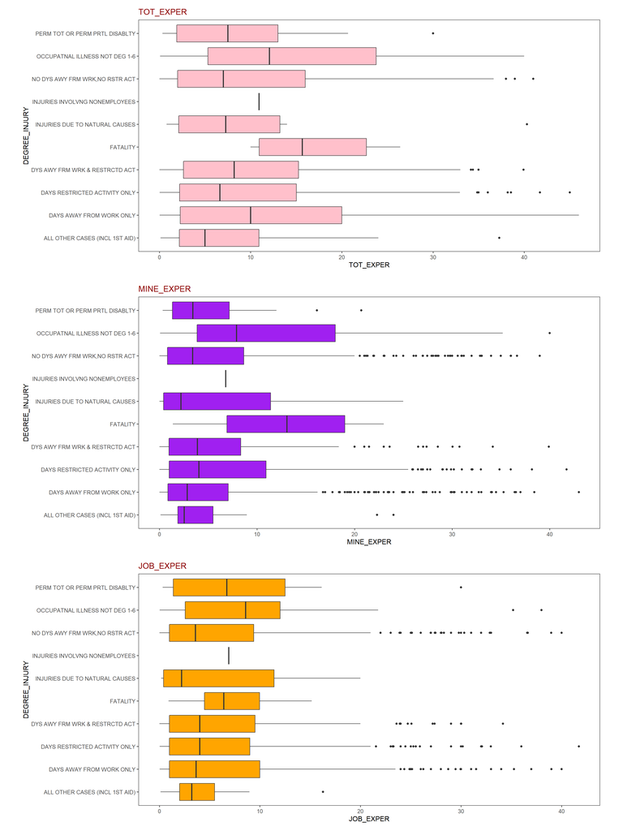

```r
p6 <- ggplot(data = newdata) +
        geom_boxplot(mapping = aes(x = TOT_EXPER, y = DEGREE_INJURY), fill = "pink")+
        ggtitle("TOT_EXPER")+
        project_theme
p7 <- ggplot(data = newdata) +
        geom_boxplot(mapping = aes(x = MINE_EXPER, y = DEGREE_INJURY),fill = "purple")+
        ggtitle("MINE_EXPER")+
        project_theme
p8 <- ggplot(data = newdata) +
        geom_boxplot(mapping = aes(x = JOB_EXPER, y = DEGREE_INJURY),fill = "orange")+
        ggtitle("JOB_EXPER")+
        project_theme
grid.arrange(p6, p7, p8, ncol=1)
```